# Basic CatBoost Example

# Installing CatBoost

Unfortunately CatBoost isn’t on CRAN, and isn’t structured so that you could install it via `remotes`::install_github`. You have to visit the GitHub releases page, find the URL for the newest R release for your OS, and install it via:

```r
binary_url <- "https://github.com/catboost/catboost/releases/download/v0.26.1/catboost-R-Darwin-0.26.1.tgz"

remotes::install_url(
  binary_url,
  INSTALL_opts = c("--no-multiarch", "--no-test-load")
)
```

While you’re at it consider installing treesnip, which allows you to use CatBoost (and lightgbm) with tidymodels:

```r
remotes::install_github("curso-r/treesnip")
```

# Preliminaries

We’ll be using the Ames housing dataset, available from the AmesHousing package.

```r
library(rsample)
library(catboost)
library(dplyr)
library(purrr)
library(ggplot2)

set.seed(1234)

ames <- AmesHousing::make_ames() %>%
  janitor::clean_names()
ames_split <- initial_split(ames, strata = "sale_price")
ames_train <- training(ames_split)
ames_test <- testing(ames_split)
```

The Ames dataset is nice for our purposes as it contains many factor variables:

```r
ames %>% map(class) %>% keep(. == "factor") %>% length()
```

```
## [1] 46
```

# Using CatBoost

One thing you should be aware of is that CatBoost prefaces each function it exports with `catboost.`:

```r
ls("package:catboost") %>% stringr::str_detect("^catboost\\.") %>% all()
```

```
## [1] TRUE
```

To use CatBoost, you’ll have to convert the datasets into a particular format. If you’re familiar with lightgbm, it looks a bit like that.

```r
ames_train_pool <- catboost.load_pool(
    data = ames_train %>% select(-sale_price),
    label = ames_train$sale_price
)

ames_test_pool <- catboost.load_pool(
    data = ames_test %>% select(-sale_price),
    label = ames_test$sale_price
)
```

You could also give it a CSV file to read, or supply it with row or group weights, etc. The documentation indicates that you should specify categorical variable indices with the argument `cat_features`, but if you do so you’ll be greeted with the message that it’s unnecessary and that you should convert your categorical features to factors.

Training a model is now pretty easily done:

```r
params <- list(
  loss_function = "RMSE",
  custom_loss = "R2",
  iterations = 500,
  depth = 8,
  learning_rate = 0.08
)

model <- catboost.train(
    learn_pool = ames_train_pool, test_pool = ames_test_pool, params = params
)
```

See the documentation for `catboost.train()` for more information on the possible configuration parameters.

I’ve hidden the output because it’s 2000 lines, but at the end it gives the following message:

```
bestTest = 23935.587
bestIteration = 492

Shrink model to first 493 iterations.
```

You can shrink the model with `catboost.shrink()`:

```r
catboost.shrink(model, 493)
```

```
## [1] TRUE
```

You don’t use base R’s `predict` function for predictions, but rather `catboost.predict()`, which works on a CatBoost pool object:

```r
test_predictions <- catboost.predict(model, ames_test_pool)

r2 <- cor(ames_test$sale_price, test_predictions)^2
r2
```

```
## [1] 0.9076073
```

Though you can also compute $R^2$ using the `catboost.eval_metrics()` function:

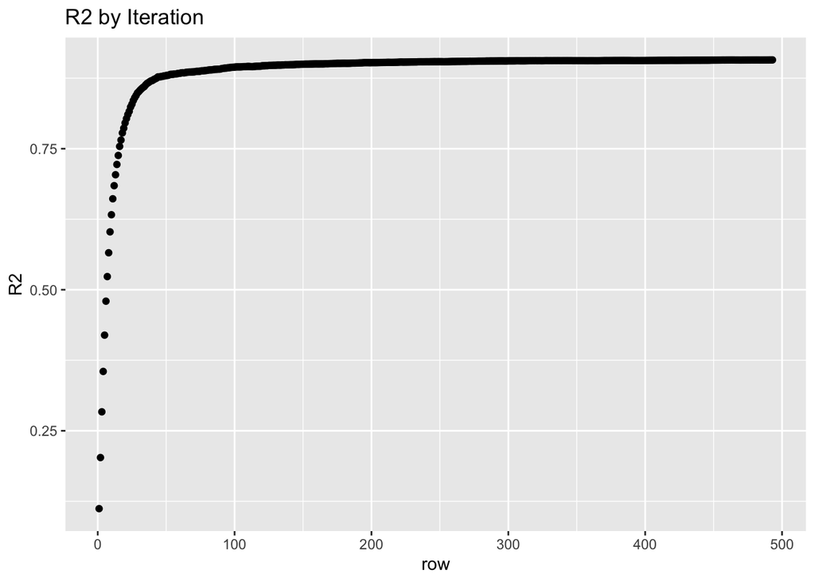

```r
catboost.eval_metrics(model, ames_test_pool, "R2") %>%
  as_tibble() %>%
  mutate(row = row_number()) %>%
  ggplot(aes(row, R2)) +
  geom_point() +
  ggtitle("R2 by Iteration")
```

You can also get feature importance:

```r
feature_importance <- catboost.get_feature_importance(
  model,
  pool = ames_test_pool,
  type = "FeatureImportance"
)

tibble(
  column = rownames(feature_importance),
  importance = feature_importance[,1]
) %>%
  arrange(desc(importance)) %>%
  head(5) %>%
  knitr::kable()
```

| column | importance |
| --- | --- |
| gr_liv_area | 13.958892 |
| overall_qual | 13.848104 |
| exter_qual | 10.109577 |
| total_bsmt_sf | 8.036430 |
| garage_cars | 4.350653 |

`catboost.get_feature_importance()` supports other `type`s, such as `ShapValues`.

# Other Useful Functions

You can find the k-fold cross validation error with `catboost.cv()`, which operates much like `catboost.train()`:

```r
cv_results <- catboost.cv(
    pool = ames_train_pool,
    params = params,
    fold_count = 3,
    partition_random_seed = 1024
)
```

```r
cv_results[which.min(cv_results$test.RMSE.mean),] %>%
  knitr::kable()
```

|  | test.RMSE.mean | test.RMSE.std | train.RMSE.mean | train.RMSE.std | test.R2.mean | test.R2.std | train.R2.mean | train.R2.std |
| --- | --- | --- | --- | --- | --- | --- | --- | --- |
| 492 | 25966.94 | 629.0298 | 5006.062 | 184.6111 | 0.8940723 | 0.0118855 | 0.9960802 | 0.0005536 |

Another function that might be useful (though we’ll not go over it here) is `catboost.caret()`, which can be passed as a `method` to `caret::train()`.